# 아프니까,,,,,, 돼지열병

돼지 2팀(허윤지, 설혁수, 권희현, 선시형, 김한솔)

2019년 12월 7일

# 0. 사용한 library

```r
df <- readxl::read_excel("AA.xlsx")
df2 <- readxl::read_excel("AA.xlsx", sheet = 2)
df3 <- readxl::read_excel("AA.xlsx", sheet = 3)
```

```
## * `` -> ...6
```

```r
library(ggplot2)
library(tidyverse)
library(plotly)
```

# 1. 국내 양돈 사육현황

## 가. 년도별 양돈 사육현황

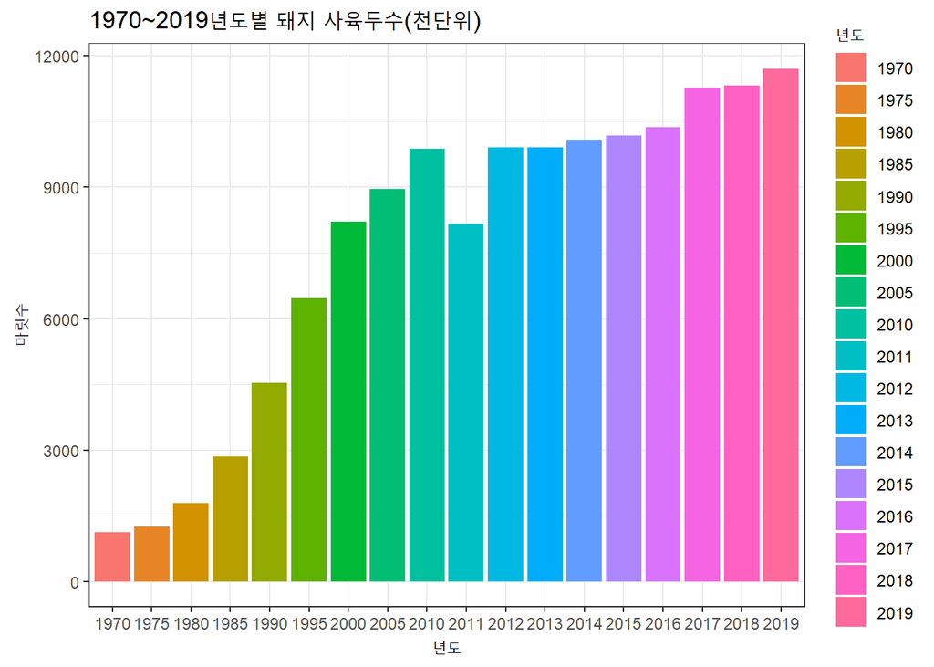

```r
df %>%
  mutate(년도 =  factor(년도)) %>%
  ggplot(aes(년도,마릿수)) +
  geom_col(aes(년도,마릿수, fill = 년도))+
  theme_bw() +
  labs( title = "1970~2019년도별 돼지 사육두수(천단위)")
```

## 나. 년도별 양돈 호수현황

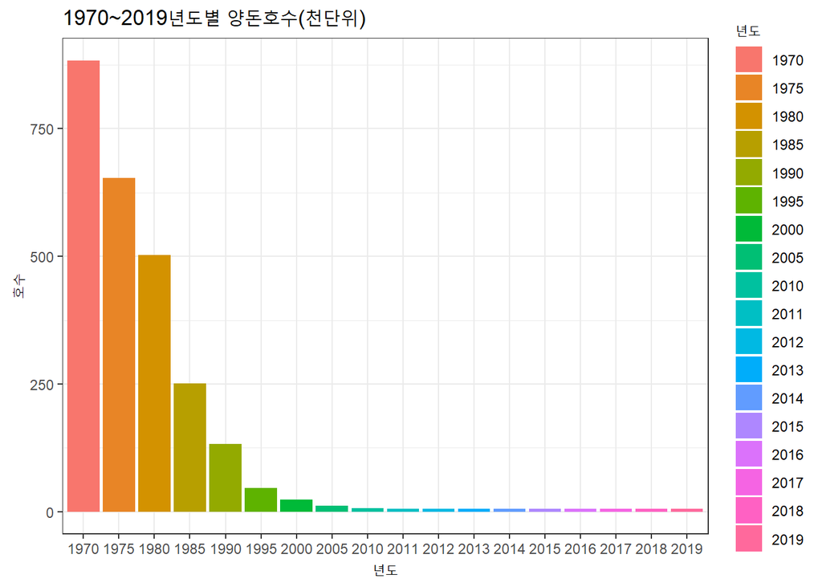

```r
df %>%
  mutate(년도 =  factor(년도)) %>%
  ggplot(aes(년도,호수)) +
  geom_col(aes(년도,호수, fill = 년도)) +
  theme_bw() +
  labs(title = "1970~2019년도별 양돈호수(천단위)")
```

다음은 연도별 양돈호수를 나타낸 그래프이다. 앞선 그래프에서 사육마리수가 크게 증가한 결과와 달리 양돈호수는 시간이 지남에 따라 크게 감소하였다. 이 결과를 통해 미루어 볼 때, 양돈산업은 축산 개별 농가의 규모화 및 기업화가 진행되어 각 호수당 사육 마릿수가 증가하였을 것이라 예측할 수 있다. 이는 다음의 ’규모별 양돈 농가호수’를 통해 더 자세히 다루도록 하자.

## 다. 년도별 두수에 따른 농가 호수

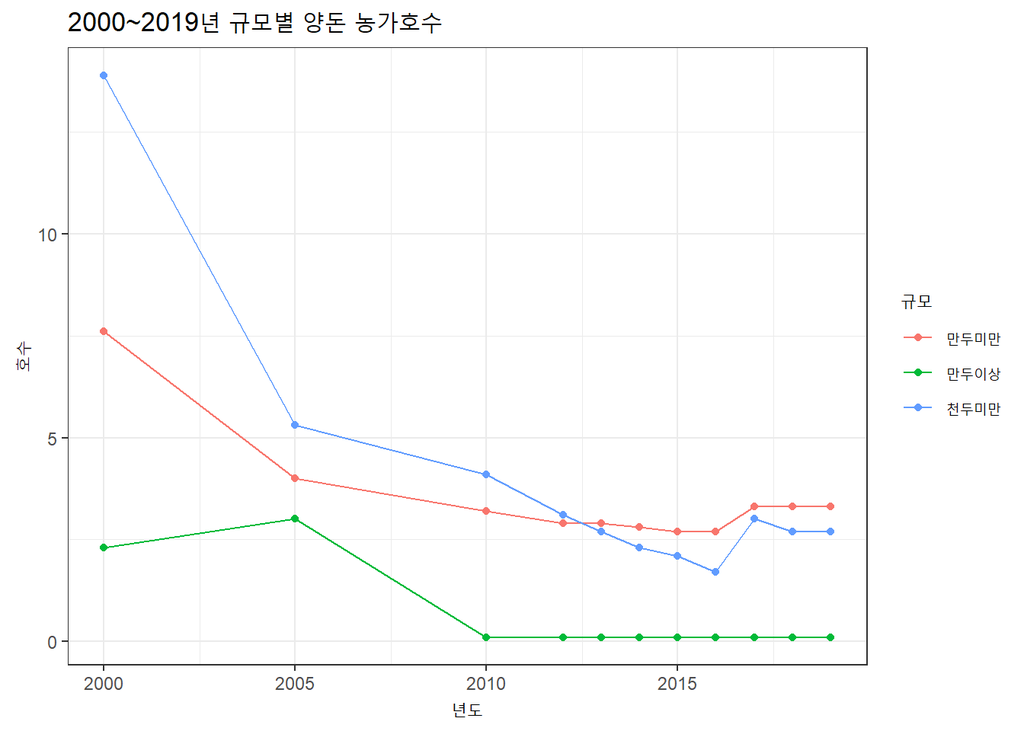

```r
df2 %>%
  gather(천두미만:만두이상, key = "규모", value = "호수") %>%
  ggplot(aes(년도, 호수, color = 규모)) +
  geom_line() +
  geom_point() +
  theme_bw() +
  labs(title = "2000~2019년 규모별 양돈 농가호수")
```

## 라. 국가별 양돈사육현황

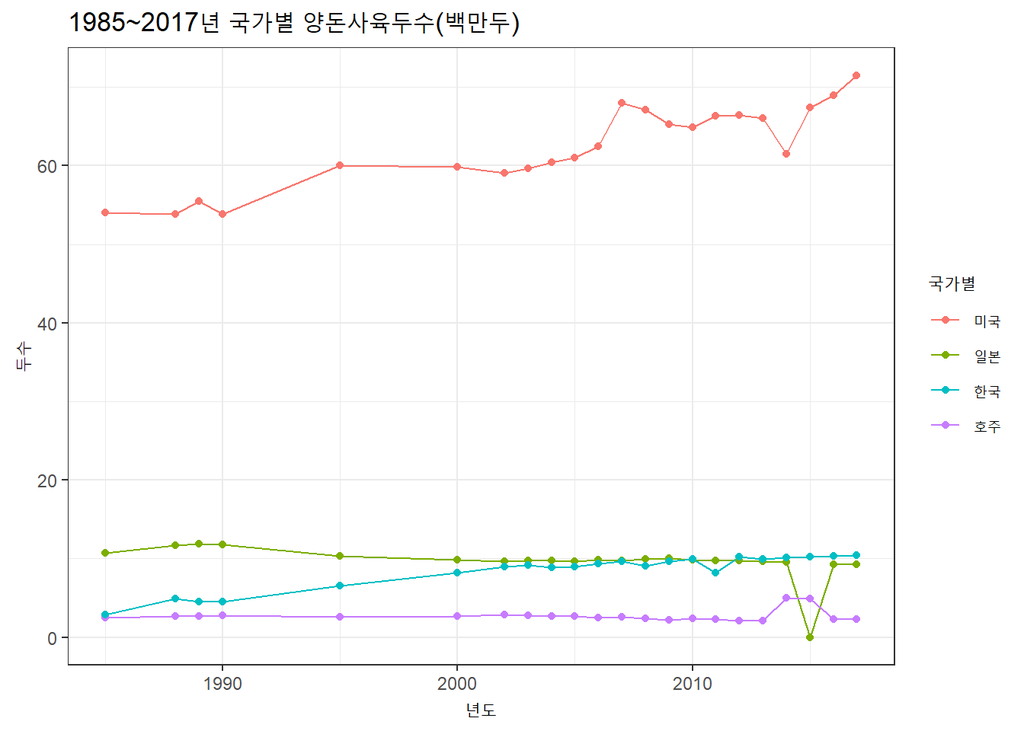

```r
df3 %>%
 gather(일본:한국, key = "국가별", value = "두수") %>%
  ggplot(aes(년도, 두수, color = 국가별)) +
  geom_line() +
  geom_point() +
  theme_bw() +
  labs(title = "1985~2017년 국가별 양돈사육두수(백만두)")
```

다음의 그래프는 1985년부터 2017년도까지의 국가별 양돈사육두수를 나타낸 그래프이다.

# 2. 돼지의 생산비, 도축현황 및 1인당 돼지고기 소비량

```r
cost <- readxl::read_excel("cost.xlsx")
supply <- readxl::read_excel("bb.xlsx", sheet = 1)
```

```
## * `` -> ...5
## * `` -> ...6
## * `` -> ...7
## * `` -> ...8
```

```r
market <- readxl::read_excel("bb.xlsx", sheet = 2)
```

## 가. 생산비 현황

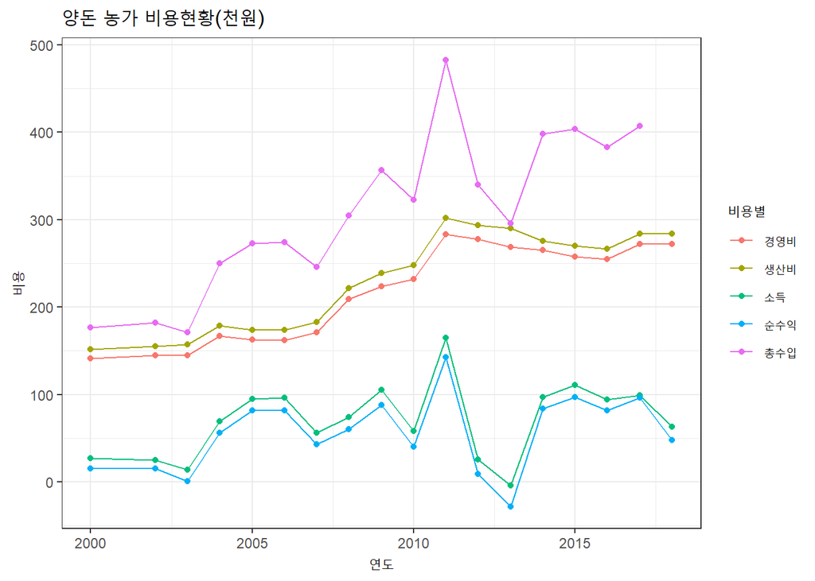

```r
cost %>%
  gather(생산비:순수익, key = "비용별", value = "비용") %>%
  ggplot(aes(연도, 비용, color = 비용별)) +
  geom_line() +
  geom_point() +
  theme_bw() +
  labs(title ="양돈 농가 비용현황(천원)")
```

다음은 양돈농가 비용현황(단위: 1000won)을 나타낸 그래프이다. 우선 눈여겨 볼 점은 소득과 순수익이 2015년 이후로 감소하는 추세임을 알 수 있다. 따라서 소득과 순수익에 가장 큰 영향을 미치는 비용(생산비와 경영비)을 낮추는 전략이 양돈산업의 지속을 위해 필수적이다. 게다가 현재 ASF로 인해 소비심리가 위축되어 있어, 공급이 늘고 소비가 줄어 돼지 1kg 당 싯가가 감소하여 농가에 막대한 피해를 주고 있다. 따라서 새로운 전략을 찾는 것이 곧 농가의 소득을 위해 필수적이다.

## 나. 수급현황(생산과 수입)

[figure not shown]

```r
supply %>%
  gather(생산: 수입, key = "수급별", value = "무게") %>%
  ggplot(aes(연도, 무게, color = 수급별)) +
  geom_line() +
  geom_point() +
  theme_bw() +
  labs(title ="1980~2017년 수급 현황(천t)")
```

## 다. 1인당 돼지고기 소비현황

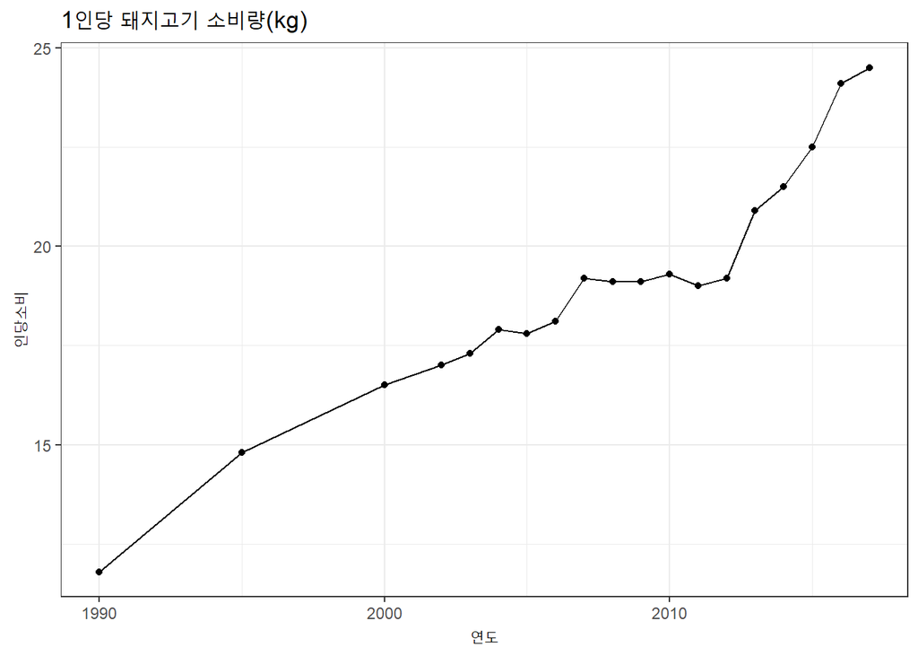

```r
supply %>%
  mutate(인당소비 = as.numeric(인당소비)) %>%
  ggplot(aes(연도, 인당소비)) +
  geom_line() +
  geom_point() +
  theme_bw() +
  labs(title = "1인당 돼지고기 소비량(kg)")
```

다음은 1인당 돼지고기 소비량(kg)을 나타낸 그래프이다. 현재 1인당 돼지고기 소비량은 꾸준히 증가하는 추세이나, ASF가 발발한 현재 1인당 돼지고기 소비량의 추이가 계속 상승할지는 미지수이다. 따라서 이후 ‘3. 아프리카 돼지열병’ 파트를 통해 ASF가 양돈산업에 미치는 영향을 자세히 알아보도록 하자.

# 3. 아프리카 돼지열병

## 가. 아프리카 돼지열병 누적 발생건수

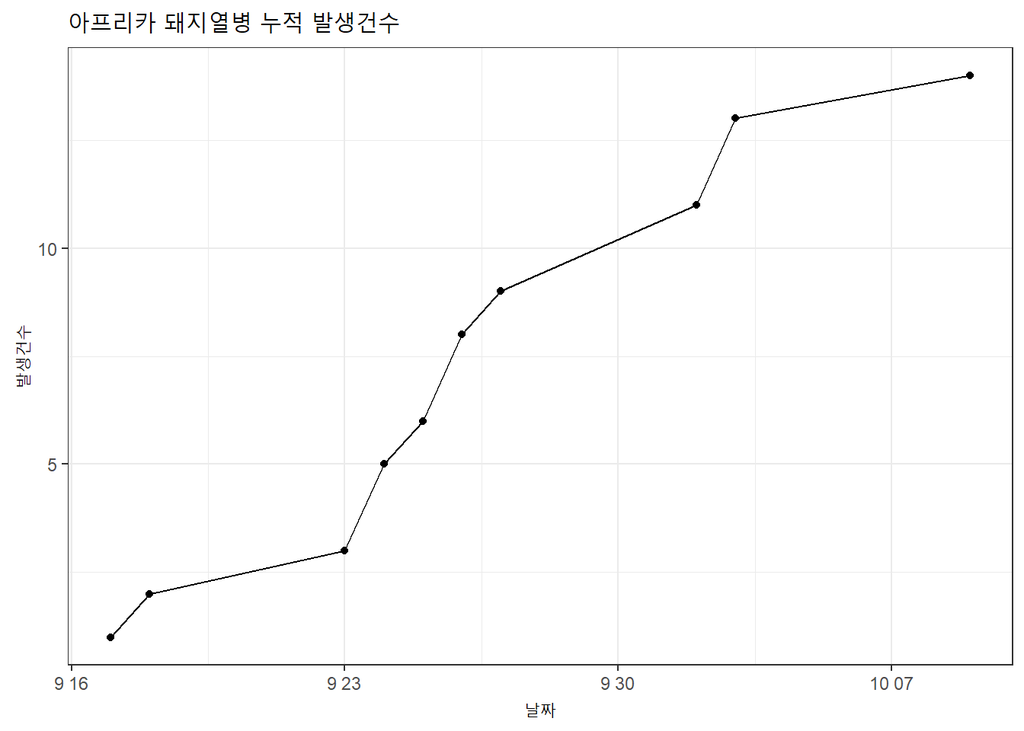

다음의 그림은 시간이 흐름에 따른 아프리카 돼지열병 누적 발생 건수이다. 다음의 그림을 통해 알 수 있듯, 아프리카 돼지열병의 발생은 sigmoidal curve를 그리고 있으며, 9월 23일부터 10월 2일까지는 급격히 상승하였으나, 그 이후로 상승세가 감소하는 추세를 보인다. 다음의 그래프는 누적매몰처분두수이다.

## 나. 아프리카돼지열병 누적 매몰처분대상 수

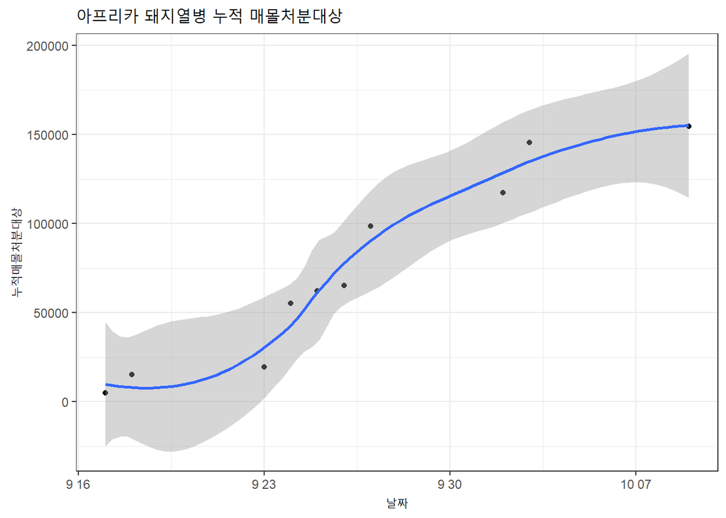

다음의 그림은 아프리카 돼지열병의 누적매몰처분 돼지의 수이다. 우선, 아프리카 돼지열병 발생건수와 유사한 양상인, sigmoidal curve를 띄고 있다. 또한 10월 9일로 현재 12월 7일까지 아프리카 돼지열병이 감지되지 않았다. 따라서 아프리카 돼지열병은 현재 잘 통제되고 있음을 짐작할 수 있다. 하지만 안정되기까지 대한민국의 양돈산업은 그 변화양상이 급격히 바뀌었다. 따라서 어느 정도 ASF의 방역이 잘 통제되기까지, ASF가 대한민국 양돈산업에 어떤 영향을 미쳤을지 조금 더 자세히 알아보도록 하자.

## 다. 2019년 1월부터 11월까지의 해외 돼지고기 수입 현황

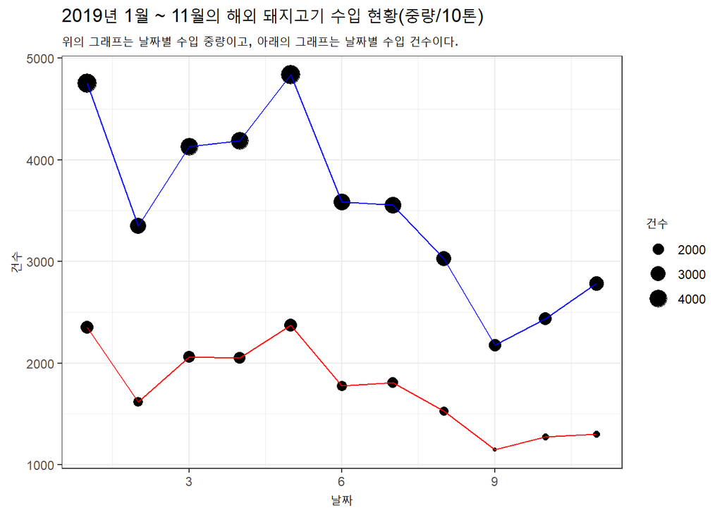

다음의 그림은 2019년 1월부터 11월까지의 해외 돼지고기 수입 현황을 나타낸 파일이다. 날짜에 따른 수입 건수와 중량(10톤)을 통해 약 5월부터 9월까지 수입량이 감소하다가, 아프리카 돼지열병이 발생한 9월부터 다시 오르는 경향을 확인할 수 있었다. 아프리카 돼지열병의 발생으로 인해 국내산 돼지고기의 안전성에 문제가 대두되자, 이를 대체할 대체육으로써 수입돼지고기의 수입량이 증가했다고 예상할 수 있다. 또한, 수입 건수와 수입중량이 유사한 양상을 가지며 변화하는 것을 통해, 수입건수당 중량(중량/수입건수, 10톤/건수)이 거의 일정한 값을 가지는 것으로 알 수 있다. 따라서 한번 수입할 때 들어오는 중량은 모두 유사하므로, 결과적으로 발생건수가 증가하였기 때문에 전체적인 수입중량이 9월부터 증가하였다고 해석하는 것이 적절하다.

## 라. 2019년 5월부터 11월까지의 평균 돼지 생체 싯가, Won/kg

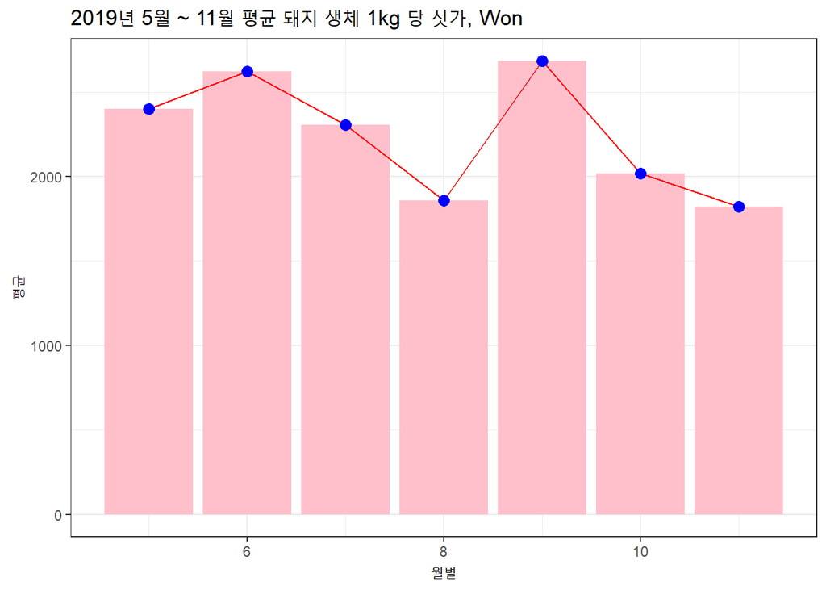

다음의 그림은 2019년 5월부터 11월까지 평균 돼지 생체 1kg 당 가격(won)이다. 9월까지는 평균싯가가 2686원/kg까지 올랐으나, 돼지열병 발생 이후 11월에는 1820원/kg까지 감소하였다. 따라서 다음 데이터를 통해 유추할 수 있는 점은 돼지열병의 발생으로 인해 살처분을 염려한 농가에서 서둘러 도축을 실시하였기 때문이라 볼 수 있다. 이로 인해 도축장에 돼지가 몰려 소비량에 비해 공급량이 과다해져, 싯가가 감소하였다. 따라서 국내 돼지고기의 공급량이 증가하고, 해외의 돼지고기의 수입은 증가하나, 소비심리는 크게 위축되어 대한민국 양돈산업에 큰 피해가 될 수 있다.

[figure not shown]

## 바. ASF 파동에 따른 돼지고기 소비의향

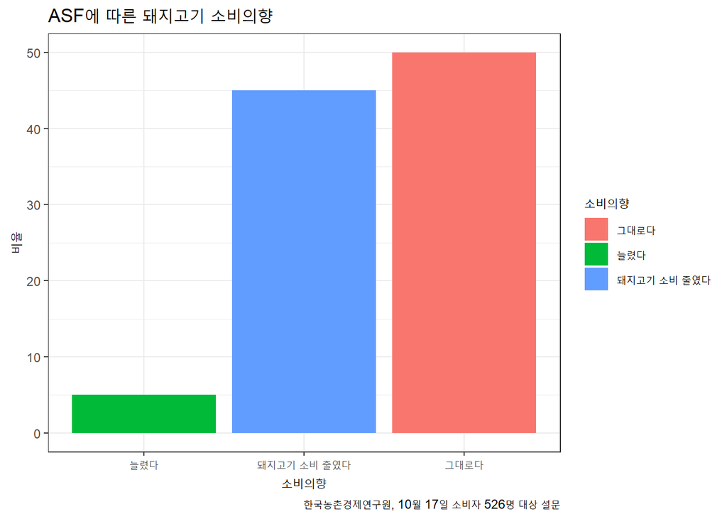

다음의 그래프는 ASF에 따른 돼지고기 소비의향을 나타낸 그래프이다. 앞서 나온 ’광우병 파동 이후 한국 소비자의 심리’와 굉장히 유사한 양상을 나타낸다. 돼지열병이 최초로 2019년 9월 17일에 발발 후, 정확히 한 달이 지났을 때 시민들에게 돼지고기 소비의향에 대해 질문했을 때, 돼지고기의 소비를 줄인 비율이 약 45%에 달한다.

# 4. 결론

’돼지 2조’는 본 과제를 수행하면서 첫째로 양돈산업 현황을 알아보았다. 둘째로 양돈농가의 생산현황을 살펴보았고, 마지막으로 아프리카 돼지열병과 한국 양돈산업의 연관성을 도출하고자 하였다. 아프리카 돼지열병이 한국 양돈산업에 미치는 영향을 다양한 그래프를 통해 알아보고, 유의미한 결과를 도출하는 시간을 가졌다. 현재 대한민국은 ASF로 인해 큰 타격을 받은 상태이지만, 현재는 조금 잠잠한 상황이다. 하지만 언제 다시 발병할지 모르므로 이에 대한 지속적인 방역을 통해 원천적으로 차단하는 것만이 다시 소비자의 심리를 돌아오게 하며, 대한민국 양돈산업이 발전할 수 있는 주춧돌이 될 것이라고 생각한다.